```python
import os
import sys
sys.path.insert(0, "../utils")
import numpy as np
import matplotlib
from matplotlib import pyplot as plt
from tqdm import tqdm

import torch
import torch.nn as nn
import torch.nn.functional as F
from torch.autograd import Variable
from torchvision.utils import save_image
import torchvision.transforms as transforms
from torchvision import datasets, models, transforms
import torchvision

from torch.utils.tensorboard import SummaryWriter
import shutil

plt.style.use('seaborn')
import seaborn as sns
sns.set_style("whitegrid", {'axes.grid' : False})

import data_loaders as dl
import helpers as h

%load_ext autoreload
%autoreload 2


device = torch.device("cuda" if torch.cuda.is_available() else "cpu")
device
```

```
device(type='cuda')
```

# Assignment 6

### Experiment 1:

- Implement a conditional DCGAN model (https://arxiv.org/abs/1411.1784)
- Train the model for conditional generation on the Fashion MNIST dataset
- Requirements:
  - Use Tensorboard, WandDB or some other experiment tracker
  - Show the capabilities of the model to generate data based on given label

Let's prepare dataset

```python
mean = np.array([0.4914, 0.4822, 0.4465])
std = np.array([0.2470, 0.2435, 0.2616])

mnist_tf = transforms.Compose([
        transforms.ToTensor(),
        transforms.Pad(2),
        transforms.Normalize(mean=(0.5, ), std=(0.5, ))
    ])

train_loader, valid_loader = dl.load_train_data('fashionmnist', 624, train_transf=mnist_tf, test_transf=mnist_tf, use_cutmix=False)
```

```python
img_shape = train_loader.dataset[0][0].shape
label = train_loader.dataset[0][1]

print(f"Image shape: {img_shape}")
print(f"Label: {label}")
```

```
Image shape: torch.Size([1, 32, 32])
Label: 9
```

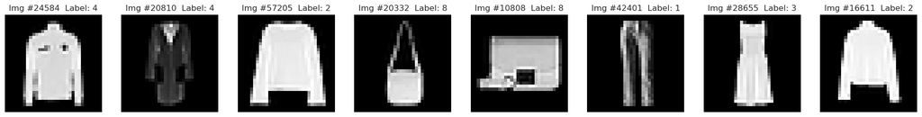

```python
N_IMGS = 8
fig, ax = plt.subplots(1,N_IMGS)
fig.set_size_inches(3 * N_IMGS, 3)

ids = np.random.randint(low=0, high=len(train_loader.dataset), size=N_IMGS)

for i, n in enumerate(ids):
    img = train_loader.dataset[n][0].numpy().reshape(32,32)
    ax[i].imshow(img, cmap='gray')
    ax[i].set_title(f"Img #{n}  Label: {train_loader.dataset[n][1]}")
    ax[i].axis("off")
plt.show()
```

```python
cDCGAN_LOGS = os.path.join(os.getcwd(), "tboard_logs", "cdcgan")
if not os.path.exists(cDCGAN_LOGS):
    os.makedirs(cDCGAN_LOGS)

shutil.rmtree(cDCGAN_LOGS)
writer = SummaryWriter(cDCGAN_LOGS)
```

```python
if not os.path.exists("imgs"):
    os.makedirs("imgs")
shutil.rmtree("imgs/training", ignore_errors=True)
if not os.path.exists("imgs/training"):
    os.makedirs("imgs/training")
```

```python
shutil.rmtree("imgs/celeb_dcgan_training", ignore_errors=True)
if not os.path.exists("imgs/celeb_dcgan_training"):
    os.makedirs("imgs/celeb_dcgan_training")
```

```python
shutil.rmtree("imgs/cdcgan_training", ignore_errors=True)
if not os.path.exists("imgs/cdcgan_training"):
    os.makedirs("imgs/cdcgan_training")
```

```python
class ConvBlock(nn.Module):
    """
    Simple convolutional block: Conv + Norm + Act + Dropout
    """

    def __init__(self, in_channels, out_channels, kernel_size=3, stride=1, add_norm=True, activation="ReLU", dropout=None):
        """ Module Initializer """
        super().__init__()
        assert activation in ["ReLU", "LeakyReLU", "Sigmoid", "Tanh", None]
        padding = kernel_size // 2

        block = []
        block.append(nn.Conv2d(in_channels, out_channels, kernel_size=kernel_size, padding=padding, stride=stride))
        if add_norm:
            block.append(nn.BatchNorm2d(out_channels))
        if activation is not None:
            nonlinearity = getattr(nn, activation, nn.ReLU)()
            if isinstance(nonlinearity, nn.LeakyReLU):
                nonlinearity.negative_slope = 0.2
            block.append(nonlinearity)

        if dropout is not None:
            block.append(nn.Dropout(dropout))

        self.block =  nn.Sequential(*block)

    def forward(self, x):
        """ Forward pass """
        y = self.block(x)
        return y


class ConvTransposeBlock(nn.Module):
    """
    Simple convolutional block: ConvTranspose + Norm + Act + Dropout
    """

    def __init__(self, in_channels, out_channels, kernel_size=3, stride=1, add_norm=True, activation="ReLU", dropout=None):
        """ Module Initializer """
        super().__init__()
        assert activation in ["ReLU", "LeakyReLU", "Tanh", None]
        padding = kernel_size // 2

        block = []
        block.append(nn.ConvTranspose2d(in_channels, out_channels, kernel_size=kernel_size, padding=1, stride=stride))
        if add_norm:
            block.append(nn.BatchNorm2d(out_channels))
        if activation is not None:
            nonlinearity = getattr(nn, activation, nn.ReLU)()
            if isinstance(nonlinearity, nn.LeakyReLU):
                nonlinearity.negative_slope = 0.2
            block.append(nonlinearity)
        if dropout is not None:
            block.append(nn.Dropout(dropout))

        self.block =  nn.Sequential(*block)

    def forward(self, x):
        """ Forward pass """
        y = self.block(x)
        return y


class Reshape(nn.Module):
    """ Reshaping a vector in a given shape """

    def __init__(self, shape):
        """ """
        super().__init__()
        self.shape = shape

    def forward(self, x):
        """ """
        B, N = x.shape
        x = x.view(B, N, 1, 1)
        y = x.repeat(1, 1, *self.shape)
        return y
```

```python
# this generator is based on the DCGAN architecture shown in the Session 6 and extended with a label input
# inspiration taken from https://github.com/togheppi/cDCGAN/blob/master/MNIST_cDCGAN_pytorch.py
class Generator(nn.Module):
    """
    A fully convolutional generator using ReLU activations.
    Takes as input a latent vector and outputs a fake sample.
       (B, latent_dim, 1, 1)  --> (B, num_channels, 32, 32)
    """
    def __init__(self, latent_dim=128, label_dim=10, num_channels=1, base_channels=32):
        """ Model initializer """
        super().__init__()

        layers = []
        latent_layers = []                       # <----------------- this layers get latent vector (gaussian noise) as input.
        label_layers = []                        # <----------------- this layers get onehot-encoded label vector as input.
        self.output_layer = None
        for i in range(4):
            if i == 0:
                latent_layers.append(
                    ConvTransposeBlock(
                            in_channels=latent_dim,
                            out_channels=base_channels * 2 ** (3-i),
                            kernel_size=4,
                            stride=1,
                            add_norm=True,
                            activation="ReLU"
                        )
                    )
                label_layers.append(
                    ConvTransposeBlock(
                            in_channels=label_dim,
                            out_channels=base_channels * 2 ** (3-i),
                            kernel_size=4,
                            stride=1,
                            add_norm=True,
                            activation="ReLU"
                        )
                    )

            else:
                layers.append(
                    ConvTransposeBlock(
                            in_channels=base_channels * 2 ** (3-i+2),       # <---------------- 2x more channels than in DCGAN from Session 6 (latent_layers and label_layers are concatenated)
                            out_channels=base_channels * 2 ** (3-i+1),      # <---------------- same
                            kernel_size=4,
                            stride=2,
                            add_norm=True,
                            activation="ReLU"
                        )
                    )

        self.output_layer = (
            ConvTransposeBlock(
                    in_channels=base_channels*2,                            # <---------------- same
                    out_channels=num_channels,
                    kernel_size=4,
                    stride=2,
                    add_norm=False,
                    activation="Tanh"
                )
            )

        self.hidden_layers = nn.Sequential(*layers)
        self.latent_layers = nn.Sequential(*latent_layers)
        self.label_layers = nn.Sequential(*label_layers)
        return

    def forward(self, x, c):
        """ Forward pass through generator """
        h1 = self.latent_layers(x)
        h2 = self.label_layers(c)
        h = torch.cat([h1, h2], dim=1)              # <----------------- concatenate outputs of latent_layers and label_layers
        h = self.hidden_layers(h)
        y = self.output_layer(h)
        return y
```

```python
# let's check if the generator works as expected

generator = Generator(latent_dim=128, num_channels=1, base_channels=32)
latent = torch.randn(16, 128, 1, 1)
label = torch.randn(16, 10, 1, 1)
fake_img = generator(latent, label)
print(f"{fake_img.shape = }")
```

```
fake_img.shape = torch.Size([16, 1, 32, 32])
```

```python
# this discriminator is based on the DCGAN architecture shown in the Session 6 and extended with a label input
# inspiration taken from https://github.com/togheppi/cDCGAN/blob/master/MNIST_cDCGAN_pytorch.py
class Discriminator(nn.Module):
    """ A fully convolutional discriminator using LeakyReLU activations.
    Takes as input either a real or fake sample and predicts its autenticity.
       (B, num_channels, 32, 32)  -->  (B, 1, 1, 1)
    """
    def __init__(self, in_channels=1, label_dim=10, out_dim=1, base_channels=32, dropout=0.3):
        """ Module initializer """
        super().__init__()

        layers = []
        image_layers = []                       # <----------------- this layers get image as input.
        label_layers = []                       # <----------------- this layers get onehot-encoded label vector as input.
        for i in range(4):
            if i == 0:
                image_layers.append(
                    ConvBlock(
                            in_channels=in_channels,
                            out_channels=base_channels * 2 ** i,
                            kernel_size=4,
                            add_norm=False,
                            activation="LeakyReLU",
                            dropout=dropout,
                            stride=2
                        )
                    )
                label_layers.append(
                    ConvBlock(
                            in_channels=label_dim,
                            out_channels=base_channels * 2 ** i,
                            kernel_size=4,
                            add_norm=False,
                            activation="LeakyReLU",
                            dropout=dropout,
                            stride=2
                        )
                    )
            else:
                layers.append(
                ConvBlock(
                        in_channels=base_channels * 2 if i == 1 else base_channels * 2 ** i,
                        out_channels=base_channels * 2 ** (i + 1),
                        kernel_size=4,
                        add_norm=True,
                        activation="LeakyReLU",
                        dropout=dropout,
                        stride=2
                    )
                )


        self.output_layer = (
                ConvBlock(
                        in_channels=base_channels * 16,
                        out_channels=out_dim,
                        kernel_size=4,
                        stride=4,
                        add_norm=False,
                        activation="Sigmoid"
                    )
                )

        self.hidden_layers = nn.Sequential(*layers)
        self.label_layers = nn.Sequential(*label_layers)
        self.image_layers = nn.Sequential(*image_layers)
        return

    def forward(self, x, c):
        """ Forward pass """
        h1 = self.image_layers(x)
        h2 = self.label_layers(c)
        # repeat the label vector to match the image size
        h2 = h2.repeat(1, 1, h1.shape[2], h1.shape[3])
        h = torch.cat([h1, h2], dim=1)              # <----------------- concatenate the two hidden layers

        h = self.hidden_layers(h)
        y = self.output_layer(h)
        return y
```

```python
# let's check if the discriminator works as expected

discriminator = Discriminator(in_channels=1, out_dim=1, base_channels=32)
score = discriminator(fake_img, label)
print(f"{score.shape = }")
```

```
score.shape = torch.Size([16, 1, 1, 1])
```

```python
import torch_fidelity #https://github.com/toshas/torch-fidelity/

class Trainer:
    """
    Class for initializing GAN and training it
    """
    def __init__(self, generator, discriminator, latent_dim=128, writer=None, isConditional=False, training_name="training", use_fidelyty_metrics=False):
        """ Initialzer """
        assert writer is not None, f"Tensorboard writer not set..."

        self.use_fidelyty_metrics = use_fidelyty_metrics
        self.isConditional = isConditional
        self.training_name = training_name
        self.latent_dim = latent_dim
        self.writer = writer
        self.device = torch.device("cuda" if torch.cuda.is_available() else "cpu")
        self.generator = generator.to(self.device)
        self.discriminator = discriminator.to(self.device)

        self.optim_discriminator = torch.optim.Adam(self.discriminator.parameters(), lr=3e-4, betas=(0.5, 0.9))
        self.optim_generator = torch.optim.Adam(self.generator.parameters(), lr=3e-4, betas=(0.5, 0.9))

        # REAL LABEL = 1
        # FAKE LABEL = 0
        # eps = 1e-10
        # self.criterion_d_real = lambda pred: torch.clip(-torch.log(1 - pred + eps), min=-10).mean()
        # self.criterion_d_fake = lambda pred: torch.clip(-torch.log(pred + eps), min=-10).mean()
        # self.criterion_g = lambda pred: torch.clip(-torch.log(1 - pred + eps), min=-10).mean()

        self.criterion_d_real = lambda pred: F.binary_cross_entropy(pred, torch.ones(pred.shape[0], device=pred.device))
        self.criterion_d_fake = lambda pred: F.binary_cross_entropy(pred, torch.zeros(pred.shape[0], device=pred.device))
        self.criterion_g = lambda pred: F.binary_cross_entropy(pred, torch.ones(pred.shape[0], device=pred.device))

        self.hist = {
            "d_real": [],
            "d_fake": [],
            "g": []
        }
        return

    def train_one_step(self, imgs, labels):
        """
        raining both models for one optimization step
        """
        if self.isConditional:
            # One hot encoding of the labels
            labels = F.one_hot(labels, num_classes=10).float()
            labels = labels.view(labels.shape[0], labels.shape[1], 1, 1)
            labels = labels.to(self.device)

        self.generator.train()
        self.discriminator.train()

        # Sample from the latent distribution
        B = imgs.shape[0]
        latent = torch.randn(B, self.latent_dim, 1, 1).to(self.device)

        # ==== Training Discriminator ====
        self.optim_discriminator.zero_grad()
        # Get discriminator outputs for the real samples
        if self.isConditional:
            prediction_real = self.discriminator(imgs, labels)
        else:
            prediction_real = self.discriminator(imgs)
        # Compute the loss function
        d_loss_real = self.criterion_d_real(prediction_real.view(B))

        # Generating fake samples with the generator
        if self.isConditional:
            fake_samples = self.generator(latent, labels)
        else:
            fake_samples = self.generator(latent)
        # Get discriminator outputs for the fake samples
        if self.isConditional:
            prediction_fake_d = self.discriminator(fake_samples.detach(), labels)
        else:
            prediction_fake_d = self.discriminator(fake_samples.detach())
        # Compute the loss function
        d_loss_fake = self.criterion_d_fake(prediction_fake_d.view(B))
        (d_loss_real + d_loss_fake).backward()
        assert fake_samples.shape == imgs.shape

        # optimization step
        torch.nn.utils.clip_grad_norm_(self.discriminator.parameters(), 3.0)
        self.optim_discriminator.step()

        # === Train the generator ===
        self.optim_generator.zero_grad()
        # Get discriminator outputs for the fake samples
        if self.isConditional:
            prediction_fake_g = self.discriminator(fake_samples, labels)
        else:
            prediction_fake_g = self.discriminator(fake_samples)
        # Compute the loss function
        g_loss = self.criterion_g(prediction_fake_g.view(B))
        g_loss.backward()
        # optimization step
        self.optim_generator.step()

        return d_loss_real, d_loss_fake, g_loss

    @torch.no_grad()
    def generate(self, N=100):
        """ Generating a bunch of images using current state of generator """
        self.generator.eval()
        latent = torch.randn(N, self.latent_dim, 1, 1).to(self.device)
        if self.isConditional:
            # generate labels
            labels = np.arange(10).repeat(10)
            # convert to torch tensor
            labels = torch.from_numpy(labels).long()
            # one hot encoding
            labels = F.one_hot(labels, num_classes=10).float()
            labels = labels.view(labels.shape[0], labels.shape[1], 1, 1)
            labels = labels.to(self.device)

            imgs = self.generator(latent, labels)
        else:
            imgs = self.generator(latent)
        imgs = imgs * 0.5 + 0.5
        return imgs

    def train(self, data_loader, N_iters=10000, init_step=0):
        """ Training the models for several iterations """

        progress_bar = tqdm(total=N_iters, initial=init_step)
        running_d_loss = 0
        running_g_loss = 0

        iter_ = 0
        for i in range(N_iters):
            for real_batch, label_batch in data_loader:
                real_batch = real_batch.to(self.device)
                d_loss_real, d_loss_fake, g_loss = self.train_one_step(imgs=real_batch, labels=label_batch)
                d_loss = d_loss_real + d_loss_fake

                # updating progress bar
                progress_bar.set_description(f"Ep {i+1} Iter {iter_}: D_Loss={round(d_loss.item(),5)}, G_Loss={round(g_loss.item(),5)})")

                # adding stuff to tensorboard
                self.writer.add_scalar(f'Loss/Generator Loss', g_loss.item(), global_step=iter_)
                self.writer.add_scalar(f'Loss/Discriminator Loss', d_loss.item(), global_step=iter_)
                self.writer.add_scalars(f'Loss/Discriminator Losses', {
                        "Real Images Loss": d_loss_real.item(),
                        "Fake Images Loss": d_loss_fake.item(),
                    }, global_step=iter_)
                self.writer.add_scalars(f'Comb_Loss/Losses', {
                            'Discriminator': d_loss.item(),
                            'Generator':  g_loss.item()
                        }, iter_)
                if(iter_ % 200 == 0):
                    imgs = self.generate()
                    grid = torchvision.utils.make_grid(imgs, nrow=10)
                    self.writer.add_image('images', grid, global_step=iter_)
                    torchvision.utils.save_image(grid, os.path.join(os.getcwd(), "imgs", self.training_name + "_training", f"imgs_{iter_}.png"))


                iter_ = iter_ + 1

            if self.use_fidelyty_metrics:
                # inspiration taken from https://github.com/toshas/torch-fidelity/blob/master/examples/sngan_cifar10.py
                metrics = torch_fidelity.calculate_metrics(
                input1=torch_fidelity.GenerativeModelModuleWrapper(self.generator, 128, "normal", 0),
                input1_model_num_samples=20,
                input2="./data/celeba/img_align_celeba_2000", # path to the folder with some images from dataset
                kid_subset_size=20,
                isc=True,
                fid=True,
                kid=True,
                #ppl=True,
                #ppl_epsilon=1e-2,
                #ppl_sample_similarity_resize=64,
                )

                # log metrics
                for k, v in metrics.items():
                    self.writer.add_scalar(f'Metrics/{k}', v, global_step=iter_)

            # saving the models
            # TODO add a checkpointing mechanism to save the model if fid score is better than before

        return
```

```python
generator = Generator(latent_dim=128, num_channels=1, base_channels=32)
discriminator = Discriminator(in_channels=1, out_dim=1, base_channels=32)

trainer = Trainer(generator=generator, discriminator=discriminator, latent_dim=128, writer=writer, isConditional=True, training_name="cdcgan")
```

```python
trainer.train(data_loader=train_loader)
```

```python
import imageio

images = []
img_path = os.path.join(os.getcwd(), "imgs", "cdcgan_training")

# making list with images and orting by iteration
img_list = [img for img in os.listdir(img_path) if "imgs_" in img]
sorted_imgs = sorted(img_list, key=lambda x: int(x.split("_")[1].split(".")[0]))

for img in sorted_imgs:
    images.append(imageio.imread(os.path.join(img_path, img)))
imageio.mimsave(os.path.join(img_path, "cdcgan_progress.gif"), images)
```

The results is good. The following image demonstrate generation (43800th iteration) of the FashionMNIST items according to the labels.  
Top to bottom :  
0: "T-shirt/Top",  
1: "Trouser",  
2: "Pullover",  
3: "Dress",  
4: "Coat",  
5: "Sandal",  
6: "Shirt",  
7: "Sneaker",  
8: "Bag",  
9: "Ankle Boot"

[figure not shown]

We can observe wide variety of forms inside of the classes

Here is the gif with the generated images in the time of training:

[figure not shown]

### Experiment 2:

- Implement a fully convolutional DCGAN-like model (https://arxiv.org/abs/1511.06434)
- Train the model on the CelebA dataset to generate new faces
- Requirements:
  - Use Tensorboard, WandDB or some other experiment tracker
  - Show the capabilities of your model to generate images
  - Evaluate and track during training using one quantitative metric (e.g. FID)

Let's download dataset

```python
transform = transforms.Compose([
        transforms.Resize(64),
        transforms.CenterCrop(64),
        transforms.ToTensor(),
        transforms.Normalize((0.5, 0.5, 0.5), (0.5, 0.5, 0.5))])

celeb_train_loader, celeb_valid_loader = dl.load_train_data('celeba', 364, train_transf=transform, test_transf=transform, use_cutmix=False)
```

```
Files already downloaded and verified
Files already downloaded and verified
```

```python
# Uncomment this cell to create a folder with 2000 images from the dataset (to use it for Fidelity metrics as input_2)

# import os
# import shutil

# src = "./data/celeba/img_align_celeba"
# src_files = os.listdir(src)
# # take only 2000 images
# src_files = src_files[:2000]
# # create a folder for the images
# dst = "./data/celeba/img_align_celeba_2000"
# if not os.path.exists(dst):
#     os.makedirs(dst)
# # resize (64x64) and copy the images
# for file_name in src_files:
#     full_file_name = os.path.join(src, file_name)
#     if (os.path.isfile(full_file_name)):
#         img = Image.open(full_file_name)
#         img = img.resize((64, 64))
#         img.save(os.path.join(dst, file_name))
```

```python
img_shape = celeb_train_loader.dataset[0][0].shape
label = celeb_train_loader.dataset[0][1]

print(f"Image shape: {img_shape}")
print(f"Label: {label}")
```

```
Image shape: torch.Size([3, 64, 64])
Label: tensor([0, 1, 1, 0, 0, 0, 0, 0, 0, 0, 0, 1, 0, 0, 0, 0, 0, 0, 1, 1, 0, 1, 0, 0,
        1, 0, 0, 1, 0, 0, 0, 1, 1, 0, 1, 0, 1, 0, 0, 1])
```

[figure not shown]

```python
N_IMGS = 8
fig, ax = plt.subplots(1,N_IMGS)
fig.set_size_inches(3 * N_IMGS, 3)

ids = np.random.randint(low=0, high=len(celeb_train_loader.dataset), size=N_IMGS)

for i, n in enumerate(ids):
    img = celeb_train_loader.dataset[n][0].numpy().transpose(1,2,0)
    img = img * 0.5 + 0.5
    ax[i].imshow(img, cmap='gray')
    ax[i].set_title(f"Img #{n}  ")
    ax[i].axis("off")
plt.show()
```

```python
# based on the code from Session 6 but has 3 input channels instead of 1 and has one more convtranspose layer

class CelebGenerator(nn.Module):
    """
    A fully convolutional generator using ReLU activations.
    Takes as input a latent vector and outputs a fake sample.
       (B, latent_dim, 1, 1)  --> (B, num_channels, 32, 32)
    """
    def __init__(self, latent_dim=256, num_channels=3, base_channels=64):
        """ Model initializer """
        super().__init__()

        layers = []
        for i in range(4):
            layers.append(
                ConvTransposeBlock(
                        in_channels=latent_dim if i == 0 else base_channels * 2 ** (3-i+1),
                        out_channels=base_channels * 2 ** (3-i),
                        kernel_size=4,
                        stride=1 if i == 0 else 2,
                        add_norm=True,
                        activation="ReLU"
                    )
                )

        layers.append(
            ConvTransposeBlock(
                    in_channels=base_channels,
                    out_channels=base_channels,
                    kernel_size=4,
                    stride=2,
                    add_norm=True,
                    activation="ReLU"
                )
            )
        layers.append(
            ConvTransposeBlock(
                    in_channels=base_channels,
                    out_channels=3,
                    kernel_size=4,
                    stride=2,
                    add_norm=False,
                    activation="Tanh"
                )
            )


        self.model = nn.Sequential(*layers)
        return

    def forward(self, x):
        # torch_fidelity sends [B, latent_dim] tensors, so we need to reshape them
        use_fidelity = False
        if len(x.shape) == 2:
            use_fidelity = True
        if use_fidelity:
            x = x.view(x.size(0), x.size(1), 1, 1)

        """ Forward pass through generator """
        y = self.model(x)
        if use_fidelity:
            # y to dtype=torch.uint8
            y = (y + 1) / 2
            y = y * 255
            y = y.to(dtype=torch.uint8)
        return y
```

```python
celeb_generator = CelebGenerator(latent_dim=512, num_channels=3, base_channels=128)
latent = torch.randn(16, 512, 1, 1)
fake_img = celeb_generator(latent)
print(f"Fake image shape: {fake_img.shape}")
```

```
Fake image shape: torch.Size([16, 3, 64, 64])
```

```python
# based on the code from Session 6 but has 3 input channels instead of 1 and has one more convolution layer

class CelebDiscriminator(nn.Module):
    """ A fully convolutional discriminator using LeakyReLU activations.
    Takes as input either a real or fake sample and predicts its autenticity.
       (B, num_channels, 32, 32)  -->  (B, 1, 1, 1)
    """
    def __init__(self, in_channels=1, out_dim=1, base_channels=64, dropout=0.3):
        """ Module initializer """
        super().__init__()

        layers = []
        for i in range(4):
            layers.append(
                ConvBlock(
                        in_channels=in_channels if i == 0 else base_channels * 2 ** i,
                        out_channels=base_channels * 2 ** (i + 1),
                        kernel_size=4,
                        add_norm=True,
                        activation="LeakyReLU",
                        dropout=dropout,
                        stride=2
                    )
                )
        layers.append(
                ConvBlock(
                        in_channels=base_channels * 16,
                        out_channels=base_channels * 16,
                        kernel_size=4,
                        stride=4,
                        add_norm=True,
                        activation="LeakyReLU",
                        dropout=dropout,
                    )
                )

        layers.append(
                ConvBlock(
                        in_channels=base_channels * 16,
                        out_channels=out_dim,
                        kernel_size=4,
                        stride=4,
                        add_norm=False,
                        activation="Sigmoid"
                    )
                )

        self.model = nn.Sequential(*layers)
        return

    def forward(self, x):
        """ Forward pass """
        y = self.model(x)
        return y
```

```python
celeb_discriminator = CelebDiscriminator(in_channels=3, out_dim=1, base_channels=128)
score = celeb_discriminator(fake_img)
print(f"Score shape: {score.shape}")
```

```
Score shape: torch.Size([16, 1, 1, 1])
```

```python
DCGAN_LOGS = os.path.join(os.getcwd(), "tboard_logs", "dcgan")
if not os.path.exists(DCGAN_LOGS):
    os.makedirs(DCGAN_LOGS)

shutil.rmtree(DCGAN_LOGS)
writer_1 = SummaryWriter(DCGAN_LOGS)
```

```python
celeb_generator = CelebGenerator(latent_dim=128, num_channels=3, base_channels=48)
celeb_discriminator = CelebDiscriminator(in_channels=3, out_dim=1, base_channels=32, dropout=0.45)
```

```python
trainer_celeb = Trainer(generator=celeb_generator, discriminator=celeb_discriminator, latent_dim=128, writer=writer_1, isConditional=False, training_name="celeb_dcgan", use_fidelyty_metrics=True)
```

```python
trainer_celeb.train(data_loader=celeb_train_loader)
```

[output not shown]

[output cut: 236 more lines]

[output not shown]

[output not shown]

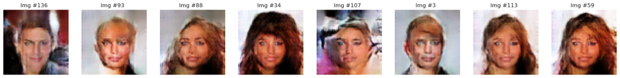

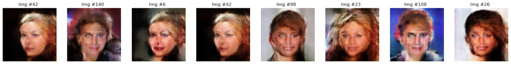

```python
def plot_fake_images():
    latent = torch.randn(160, 128, 1, 1)
    fake_imgs = celeb_generator(latent.to(device))
    fake_imgs = fake_imgs.detach().cpu().numpy()

    N_IMGS = 8
    fig, ax = plt.subplots(1,N_IMGS)
    fig.set_size_inches(3 * N_IMGS, 3)

    ids = np.random.randint(low=0, high=len(fake_imgs), size=N_IMGS)

    for i, n in enumerate(ids):
        img = fake_imgs[n].transpose(1,2,0)
        img = img * 0.5 + 0.5
        ax[i].imshow(img, cmap='gray')
        ax[i].set_title(f"Img #{n}  ")
        ax[i].axis("off")
    plt.show()

plot_fake_images()
plot_fake_images()
```

```python
import imageio

images = []
img_path = os.path.join(os.getcwd(), "imgs", "celeb_dcgan_training")

# making list with images and orting by iteration
img_list = [img for img in os.listdir(img_path) if "imgs_" in img]
sorted_imgs = sorted(img_list, key=lambda x: int(x.split("_")[1].split(".")[0]))

for img in sorted_imgs:
    images.append(imageio.imread(os.path.join(img_path, img)))
imageio.mimsave(os.path.join(img_path, "celeb_dcgan_progress.gif"), images)
```

The results is good. The following image demonstrate generation (12200th iteration) of faces.

[figure not shown]

There are different faces, there are also variations of the same fake-celebs with a bit different head_possition/hear/light/something_else

They all look weird, but in every image I can recognize a face

Here is the gif with the generated images in the time of training:

[figure not shown]